# Comcast Telecom Consumer Complaints. Project 2

Swati

20/01/2021

# Comcast Telecom Consumer Complaints-Project 2

## **Brief Description of the Project**

DESCRIPTION

Comcast is an American global telecommunication company. The firm has been providing terrible customer service. They continue to fall short despite repeated promises to improve. Only last month (October 2016) the authority fined them a $2.3 million, after receiving over 1000 consumer complaints.

The existing database will serve as a repository of public customer complaints filed against Comcast. It will help to pin down what is wrong with Comcast’s customer service.

Data Dictionary

1.Ticket : Ticket number assigned to each complaint

2.Customer Complaint: Description of complaint

3.Date: Date of complaint

4.Time: Time of complaint

5.Received Via: Mode of communication of the complaint

6.City: Customer city

7.State: Customer state

8.Zipcode: Customer zip

9.Status: Status of complaint

10.Filing on behalf of someone

## **Objective 1:Import data into R environment**

```r
telecom <- read.csv("F:/data science/R/Datasets/Project_Simplilearn/Comcast Telecom Consumer Complaints/Comcast Telecom Consumer Complaints/Comcast Telecom Complaints data.csv",
                   stringsAsFactors = FALSE )
```

## **Objective 2:Provide the trend chart for the number of complaints at monthly and daily granularity levels**

```r
head(telecom, 5)
```

```
##   Ticket..                                                Customer.Complaint
## 1   250635                                     Comcast Cable Internet Speeds
## 2   223441                      Payment disappear - service got disconnected
## 3   242732                                                 Speed and Service
## 4   277946 Comcast Imposed a New Usage Cap of 300GB that punishes streaming.
## 5   307175                        Comcast not working and no service to boot
##         Date        Time       Received.Via     City    State Zip.code Status
## 1 22-04-2015  3:53:50 PM Customer Care Call Abingdon Maryland    21009 Closed
## 2   4/8/2015 10:22:56 AM           Internet  Acworth  Georgia    30102 Closed
## 3 18-04-2015  9:55:47 AM           Internet  Acworth  Georgia    30101 Closed
## 4   5/7/2015 11:59:35 AM           Internet  Acworth  Georgia    30101   Open
## 5 26-05-2015  1:25:26 PM           Internet  Acworth  Georgia    30101 Solved
##   Filing.on.Behalf.of.Someone
## 1                          No
## 2                          No
## 3                         Yes
## 4                         Yes
## 5                          No
```

Since attribute Date is not in a single format(4/08/2015 and 26-05-2015), it is required to present the Date Column in one single format for better understanding.

**formatting date**

```r
date_format1 <-strptime(telecom$Date, format = "%d-%m-%Y")
date_format2 <- strptime(telecom$Date, format = "%d/%m/%Y" )
date_format1[is.na(date_format1)] <- date_format2[!is.na(date_format2)]
date_format1 <-as.Date(date_format1)

telecom$Date <- date_format1
```

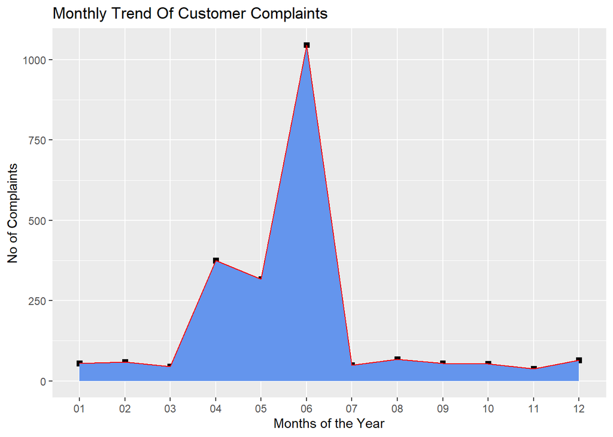

```r
months <- format(telecom$Date, "%m")
data=data.frame(table(months))

monthlytrend <- ggplot(data=data , aes(x=months, y=Freq, group=1))+
  geom_path(color = "red")+
  ggtitle("Monthly Trend Of Customer Complaints")+geom_point(size=2, shape=22, fill="black")+geom_area(color="red", fill="cornflowerblue")+xlab("Months of the Year")+
  ylab("No of Complaints")
monthlytrend
```

According to Monthly Trend Of Customer Complaints Graph, maximum complaints were received in the months April, May and June. The financial year starts from April and alot of pending works are completed during this period and hence more utilization of Network bandwidth so we can infer that this could be the reason of maximum complaints registered during this period.

```r
day <- format(telecom$Date, "%a")
table(day)
```

```
## day
## Fri Mon Sat Sun Thu Tue Wed
## 290 256 214 228 331 464 441
```

There is one more trend which can be noted here i.e, most of the complaints are registered on Tuesday and Wednesday and least on Saturday which is the family day of the week. Howsoever the trend is not so prominent.

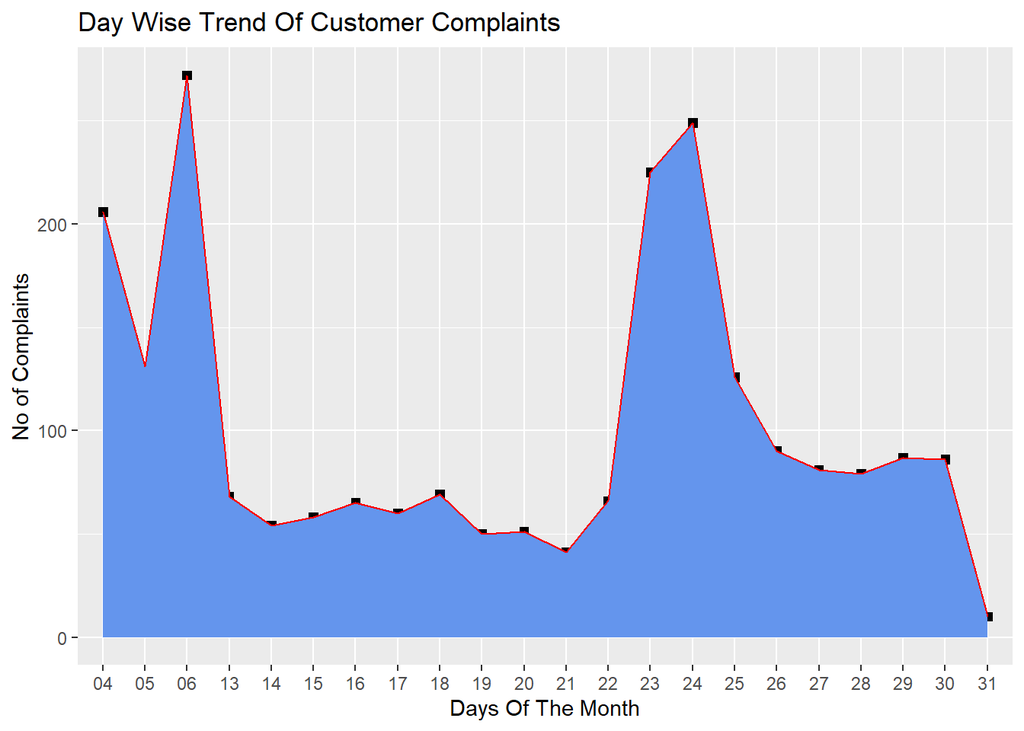

```r
date <- format(telecom$Date, "%d")
x=data.frame(table(date))

daytrend <- ggplot(data=x , aes(x=date, y=Freq, group=5))+
  geom_path(color = "red")+
  ggtitle("Day Wise Trend Of Customer Complaints")+geom_point(size=2, shape=22, fill="black")+geom_area(color="red", fill="cornflowerblue")+xlab("Days Of The Month")+
  ylab("No of Complaints")
daytrend
```

From the above graph we can depict that maximum number of complaints are registered in the starting(4th,5th,6th of the months) and end(23rd and 24th of the months)of the months.

## **Objective3:Provide a table with the frequency of complaint types**

It is very important to figure out the major issues for which the complaints are being registered in order to improve Comcast Overall Performance and Market Image.

The registered complaints are not divided in specific categories howsoever the nature of the Customer.Complaint column is available in Random, i.e for the service issue the registered complaints are “Throttling service and unreasonable data caps”,“Horrible Internet Service”,“Comcast not working and no service to boot” etc. It is required to divide Complaints in major categories like Service, Internet and Billing. There could be other categories as well howsoever majority of the complaints are registered around these issues.

```r
Service_Issue <- grep("ervice", telecom$Customer.Complaint, ignore.case = FALSE)
Internet_Issue <- grep("net", telecom$Customer.Complaint, ignore.case = FALSE)
Overbilling_Issue <- grep("bill", telecom$Customer.Complaint,ignore.case = FALSE)

complaint_types <- c(length(Service_Issue), length(Internet_Issue), length(Overbilling_Issue))
table(complaint_types)
```

```
## complaint_types
## 184 482 534
##   1   1   1
```

Here 1200 of the total complaints belong to 3 categories i.e,Service, Internet and Billing.

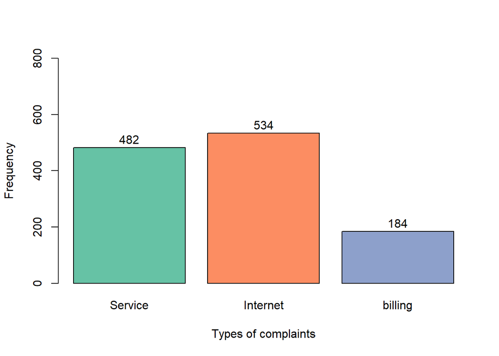

```r
complaint.types <- barplot(complaint_types,
        col = brewer.pal(3 , "Set2"),
        xlab = "Types of complaints",
        ylab = "Frequency",
        names.arg= c("Service", "Internet", "billing"),
        ylim = c(0,800))
text(x= complaint.types , y=complaint_types +30 ,labels = complaint_types )
```

## **Objective4:Provide state wise status of complaints in a stacked bar chart**

Create a new categorical variable with value as Open and Closed.Open & Pending is to be categorized as Open and Closed & Solved is to be categorized as Closed.

```r
telecom[telecom$Status=="Solved", "Status"] <- "Closed"
telecom[telecom$Status=="Pending" ,"Status" ] <- "Open"
Status.State <-table(telecom$Status, telecom$State)
Status.State
```

```
##
##          Alabama Arizona Arkansas California Colorado Connecticut Delaware
##   Closed      17      14        6        159       58           9        8
##   Open         9       6        0         61       22           3        4
##
##          District of Columbia District Of Columbia Florida Georgia Illinois
##   Closed                    1                   14     201     208      135
##   Open                      0                    2      39      80       29
##
##          Indiana Iowa Kansas Kentucky Louisiana Maine Maryland Massachusetts
##   Closed      50    1      1        4        12     3       63            50
##   Open         9    0      1        3         1     2       15            11
##
##          Michigan Minnesota Mississippi Missouri Montana Nevada New Hampshire
##   Closed       92        29          23        3       1      1             8
##   Open         23         4          16        1       0      0             4
##
##          New Jersey New Mexico New York North Carolina Ohio Oregon Pennsylvania
##   Closed         56         11        6              3    3     36          110
##   Open           19          4        0              0    0     13           20
##
##          Rhode Island South Carolina Tennessee Texas Utah Vermont Virginia
##   Closed            1             15        96    49   16       2       49
##   Open              0              3        47    22    6       1       11
##
##          Washington West Virginia
##   Closed         75             8
##   Open           23             3
```

There are states with huge number of complaints. On the contrary there are states with very few registered complaints. Let us see the states from which huge number of complaints are coming

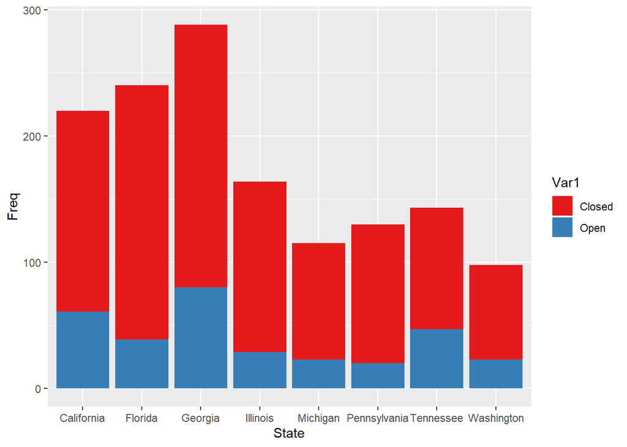

```r
m<-data.frame(table(telecom$State))
m1<-m %>% filter(Freq>80)
colnames(m1)[colnames(m1)=="Var1"] <- "State"
colnames(m1)[colnames(m1)=="Freq"] <- "Total"
Status.State.df <-data.frame(Status.State)
colnames(Status.State.df)[colnames(Status.State.df)=="Var2"] <- "State"
data_set <- merge(m1, Status.State.df,by = "State" , all.x = T)

ggplot(data = data_set, mapping = aes(x=State, y=Freq, fill=Var1)) +geom_col()+scale_fill_brewer(palette ="Set1" )
```

There are many states for which the total number of Open cases are less than 20, the company needs to solve these issues on priority. On the other hand there are countries with huge number of open complaints.

```r
State_OpenCases <- filter(data.frame(Status.State), Var1=="Open" & Freq > 20)
State_OpenCases
```

```
##   Var1       Var2 Freq
## 1 Open California   61
## 2 Open   Colorado   22
## 3 Open    Florida   39
## 4 Open    Georgia   80
## 5 Open   Illinois   29
## 6 Open   Michigan   23
## 7 Open  Tennessee   47
## 8 Open      Texas   22
## 9 Open Washington   23
```

There are total 9 States with huge number of complaints.

```r
State_name <-State_OpenCases$Var2[State_OpenCases$Freq == max(State_OpenCases$Freq)]
Max_Value  <-max(State_OpenCases$Freq)
cat("The state with maximum number of open cases is", as.character(State_name), "with total", Max_Value, "open cases")
```

```
## The state with maximum number of open cases is Georgia with total 80 open cases
```

## **Objective5:Which state has the highest percentage of unresolved complaints**

```r
State_OpenCases["Percentage"] <- (State_OpenCases$Freq/sum(State_OpenCases$Freq))*100
State_Percentage <- State_OpenCases$Var2[State_OpenCases$Percentage == max(State_OpenCases$Percentage)]
Max_Percentage <- max(State_OpenCases$Percentage)

cat(as.character(State_Percentage), "is the state with maximum", Max_Percentage, "% of total open cases")
```

[output not shown]

```r
Closed_CustomerCare_percent<-(sum(telecom$Status=="Closed" & telecom$Received.Via=="Customer Care Call")/sum(telecom$Status=="Closed"))*100

Closed_Internet_percent <-(sum(telecom$Status=="Closed" & telecom$Received.Via=="Internet")/sum(telecom$Status=="Closed"))*100

cat("The total percentage of resolved complaint via Customer Care Call is ", Closed_CustomerCare_percent,"%","\n","The total percentage of resolved complaints vis Internet is ", Closed_Internet_percent)
```

```
## The total percentage of resolved complaint via Customer Care Call is  50.61511 %
##  The total percentage of resolved complaints vis Internet is  49.38489
```